# Проект "Заведения общественного питания г.Москвы"

Дата: 06.04.2025

### Цели и задачи проекта

Исследование и анализ рынка общественного питания города Москвы с целью выбора подходящего места для нового заведения - кафе, ресторана или бара. Выбрать для нового заведения меню и ценовую политику.

### Описание данных

В анализе используются 2 датасета.

Датасет **rest_info.csv**, содержит информацию о заведениях общественного питания:

- **name** — название заведения;
- **address** — адрес заведения;
- **district** — административный район, в котором находится заведение, например Центральный административный округ;
- **category** — категория заведения, например «кафе», «пиццерия» или «кофейня»;
- **hours** — информация о днях и часах работы;
- **rating** — рейтинг заведения по оценкам пользователей в Яндекс Картах (высшая оценка — 5.0);
- **chain** — число, выраженное 0 или 1, которое показывает, является ли заведение сетевым (для маленьких сетей могут встречаться ошибки):
  - 0 — заведение не является сетевым,
  - 1 — заведение является сетевым;
- **seats** — количество посадочных мест.

Датасет **rest_price.csv** содержит информацию о среднем чеке в заведениях общественного питания:

- **price** — категория цен в заведении, например «средние», «ниже среднего», «выше среднего» и так далее;
- **avg_bill** — строка, которая хранит среднюю стоимость заказа в виде диапазона, например:
  - «Средний счёт: 1000–1500 ₽»;
  - «Цена чашки капучино: 130–220 ₽»;
  - «Цена бокала пива: 400–600 ₽».
- **middle_avg_bill** — число с оценкой среднего чека, которое указано только для значений из столбца avg_bill, начинающихся с подстроки «Средний счёт»:
  - Если в строке указан ценовой диапазон из двух значений, в столбец войдёт медиана этих двух значений.
  - Если в строке указано одно число — цена без диапазона, то в столбец войдёт это число.
  - Если значения нет или оно не начинается с подстроки «Средний счёт», то в столбец ничего не войдёт.
- **middle_coffee**_cup — число с оценкой одной чашки капучино, которое указано только для значений из столбца avg_bill, начинающихся с подстроки «Цена одной чашки капучино»:
  - Если в строке указан ценовой диапазон из двух значений, в столбец войдёт медиана этих двух значений.
  - Если в строке указано одно число — цена без диапазона, то в столбец войдёт это число.
  - Если значения нет или оно не начинается с подстроки «Цена одной чашки капучино», то в столбец ничего не войдёт.

### План проекта

0.1. Цели и задачи проекта

0.2. Описание данных

1. Загрузка данных и знакомство с ними

   1.1. Промежуточный вывод

   1.2. Подготовка единого датафрейма
2. Предобработка данных

   2.1. Преобразование типов данных

   2.2. Наличие пропусков в данных

   2.3. Изучение уникальных значений в категориальных данных

   2.4. Заполнение пропусков в данных

   2.5. Проверка на дубликаты

   2.6. Создание дополнительных столбцов

   2.7. Промежуточный вывод
3. Исследовательский анализ данных
4. Итоговый вывод и рекомендации

## Загрузка данных и знакомство с ними

Сначала загрузим необходимые для работы библиотеки:

- **pandas** - для работы с данными,
- **matplotlib** и **seaborn** - для визуализации данных,
- **phik** - для построения матрицы корреляции.

Затем выгрузим данные из файлов `/datasets/rest_info.csv` и `/datasets/rest_price.csv` в переменные **rest** и **price**.

```python
# Загружаем библиотеку Pandas
import pandas as pd
```

```python
# Загружаем библиотеки для визуализации данных
import matplotlib.pyplot as plt
import seaborn as sns
```

```python
# Уменьшение разрешения DPI для графиков
plt.rcParams['figure.dpi'] = 72
```

```python
#Для корректной работы устанавливаем библиотеку phik
#!pip install phik
# %pip install phik
```

```python
# Загружаем библиотеку для расчёта коэффициента корреляции phi_k
from phik import phik_matrix
```

```python
# Загружаем библиотеку numpy и настраиваем вывод числе бкз плавающей точки
import numpy as np
np.set_printoptions(suppress=True, precision=3)
```

```python
# Выгружаем данные из датасета `/datasets/rest_info.csv` в датафрейм rest
try:
    #пробуем загрузить
    rest = pd.read_csv('datasets/rest_info.csv')
    display('Данные успешно загружены')
except:
    # если не получилось
    display('Ошибка при загрузке файла')
```

```
'Данные успешно загружены'
```

```python
# Выгружаем данные из датасета `/datasets/rest_price.csv` в датафрейм price
try:
    #пробуем загрузить
    price = pd.read_csv('datasets/rest_price.csv')
    display('Данные успешно загружены')
except:
    # если не получилось
    display('Ошибка при загрузке файла')
```

```
'Данные успешно загружены'
```

Познакомимся с данными датасетов - выведем информацию о датафрейме методом info() и первые строки методом head()

```python
# Выводим информацию о датафрейме rest
rest.info()
```

```
<class 'pandas.core.frame.DataFrame'>
RangeIndex: 8406 entries, 0 to 8405
Data columns (total 9 columns):
 #   Column    Non-Null Count  Dtype
---  ------    --------------  -----
 0   id        8406 non-null   object
 1   name      8406 non-null   object
 2   category  8406 non-null   object
 3   address   8406 non-null   object
 4   district  8406 non-null   object
 5   hours     7870 non-null   object
 6   rating    8406 non-null   float64
 7   chain     8406 non-null   int64
 8   seats     4795 non-null   float64
dtypes: float64(2), int64(1), object(6)
memory usage: 591.2+ KB
```

```python
# Выводим первые 10 строк датафрейма rest на экран
rest.head(10)
```

|  | id | name | category | address | district | hours | rating | chain | seats |
| --- | --- | --- | --- | --- | --- | --- | --- | --- | --- |
| 0 | 0c3e3439a8c64ea5bf6ecd6ca6ae19f0 | WoWфли | кафе | Москва, улица Дыбенко, 7/1 | Северный административный округ | ежедневно, 10:00–22:00 | 5.0 | 0 | NaN |
| 1 | 045780ada3474c57a2112e505d74b633 | Четыре комнаты | ресторан | Москва, улица Дыбенко, 36, корп. 1 | Северный административный округ | ежедневно, 10:00–22:00 | 4.5 | 0 | 4.0 |
| 2 | 1070b6b59144425896c65889347fcff6 | Хазри | кафе | Москва, Клязьминская улица, 15 | Северный административный округ | пн-чт 11:00–02:00; пт,сб 11:00–05:00; вс 11:00... | 4.6 | 0 | 45.0 |
| 3 | 03ac7cd772104f65b58b349dc59f03ee | Dormouse Coffee Shop | кофейня | Москва, улица Маршала Федоренко, 12 | Северный административный округ | ежедневно, 09:00–22:00 | 5.0 | 0 | NaN |
| 4 | a163aada139c4c7f87b0b1c0b466a50f | Иль Марко | пиццерия | Москва, Правобережная улица, 1Б | Северный административный округ | ежедневно, 10:00–22:00 | 5.0 | 1 | 148.0 |
| 5 | 8a343546b24e4a499ad96eb7d0797a8a | Sergio Pizza | пиццерия | Москва, Ижорская улица, вл8Б | Северный административный округ | ежедневно, 10:00–23:00 | 4.6 | 0 | NaN |
| 6 | 96ebceb1a09e4e3191133b9fe0379a64 | Огни города | бар,паб | Москва, Клязьминская улица, 9, стр. 3 | Северный административный округ | пн 15:00–04:00; вт-вс 15:00–05:00 | 4.4 | 0 | 45.0 |
| 7 | 0243288b78024af090b8e947842c969c | Mr. Уголёк | быстрое питание | Москва, Клязьминская улица, 9, стр. 3 | Северный административный округ | пн-чт 10:00–22:00; пт,сб 10:00–23:00; вс 10:00... | 4.7 | 0 | 45.0 |
| 8 | 36aeb0ffa69c48fdb0021549520deb10 | Donna Maria | ресторан | Москва, Дмитровское шоссе, 107, корп. 4 | Северный административный округ | ежедневно, 10:00–22:00 | 4.8 | 0 | 79.0 |
| 9 | 487167877eb04288bc90d4fa80646fc2 | Готика | кафе | Москва, Ангарская улица, 39 | Северный административный округ | ежедневно, 12:00–00:00 | 4.3 | 0 | 65.0 |

Датафрейм **rest** содержит **9** столбцов и **8406** строк. Кроме заявленных в задании столбцов, присутствует столбец **id**, предположительно, первичный ключ - идентификатор заведения. Данные соответствуют заявленным и содержат информацию о заведениях общественного питания. В данных присутствуют пропуски в столбцах **hours** и **seats**.

```python
# Проверим столбец id на уникальность
rest['id'].nunique()
```

```
8406
```

Количество уникальных значений столбца **id** - 8406, столько же, сколько строк в датафрейме **rest**. Считаем **id** первичным ключом заведения.

**Изучим типы данных датафрейма rest и их корректность**

Строковые данные (object). **6** столбцов:

- id - идентификатор заведения
- name - название заведения
- category - категория
- address - адрес
- district - административный округ
- hours - часы работы

**id** содержит буквы и цифры, использование типа данных object - корректно. Остальные поля также содержат текстовую информацию, поэтому использование типа данных object - корректно. Возможно, в дальнейшем следует выделить в отдельный столбец данные из **'hours'** (часы работы заведения) в формате интервала.

**Числа с плавающей точкой (float64).** 2 столбца:

- rating - рейтинг
- seats - количество посадочных мест

Для столбца **rating** - использование типа данных float64 - корректно. Для столбца **seats** - нет. Далее преобразуем его в целочисленный тип.

**Целочисленный тип (int64 )** 1 столбец:

- chain - является ли заведение сетевым (0 — нет, 1- да). Удобнее преобразовать этот столбец в тип 'boolean'

```python
# Выводим информацию о датафрейме price
price.info()
```

```
<class 'pandas.core.frame.DataFrame'>
RangeIndex: 4058 entries, 0 to 4057
Data columns (total 5 columns):
 #   Column             Non-Null Count  Dtype
---  ------             --------------  -----
 0   id                 4058 non-null   object
 1   price              3315 non-null   object
 2   avg_bill           3816 non-null   object
 3   middle_avg_bill    3149 non-null   float64
 4   middle_coffee_cup  535 non-null    float64
dtypes: float64(2), object(3)
memory usage: 158.6+ KB
```

```python
# Выводим первые 10 строк датафрейма price на экран
price.head(10)
```

|  | id | price | avg_bill | middle_avg_bill | middle_coffee_cup |
| --- | --- | --- | --- | --- | --- |
| 0 | 045780ada3474c57a2112e505d74b633 | выше среднего | Средний счёт:1500–1600 ₽ | 1550.0 | NaN |
| 1 | 1070b6b59144425896c65889347fcff6 | средние | Средний счёт:от 1000 ₽ | 1000.0 | NaN |
| 2 | 03ac7cd772104f65b58b349dc59f03ee | NaN | Цена чашки капучино:155–185 ₽ | NaN | 170.0 |
| 3 | a163aada139c4c7f87b0b1c0b466a50f | средние | Средний счёт:400–600 ₽ | 500.0 | NaN |
| 4 | 8a343546b24e4a499ad96eb7d0797a8a | средние | NaN | NaN | NaN |
| 5 | 96ebceb1a09e4e3191133b9fe0379a64 | средние | Средний счёт:199 ₽ | 199.0 | NaN |
| 6 | 0243288b78024af090b8e947842c969c | средние | Средний счёт:200–300 ₽ | 250.0 | NaN |
| 7 | 36aeb0ffa69c48fdb0021549520deb10 | средние | Средний счёт:от 500 ₽ | 500.0 | NaN |
| 8 | 487167877eb04288bc90d4fa80646fc2 | средние | Средний счёт:1000–1200 ₽ | 1100.0 | NaN |
| 9 | ac32978af97641bfacf996e7f5a50ee5 | средние | Цена бокала пива:250–350 ₽ | NaN | NaN |

Датафрейм **price** содержит **5** столбцов и **4058** строк. Кроме заявленных в задании столбцов, присутствует столбец **id**, предположительно, первичный ключ - идентификатор заведения. Данные соответствуют заявленным и содержат информацию о ценах в заведениях общественного питания. Во всех столбцах, кроме **id**, присутствуют пропуски.

```python
# Проверим столбец id на уникальность
price['id'].nunique()
```

```
4058
```

Количество уникальных значений столбца **id** - 4058, столько же, сколько строк в датафрейме **price**. Считаем **id** первичным ключом заведения.

**Изучим типы данных датафрейма price и их корректность**

Строковые данные (object). **3** столбца:

- id - идентификатор заведения
- price - текстовое выражение ценовой категории заведения
- avg_bill - строка с текстом со средней стоимостью заказа

**id** содержит буквы и цифры, использование типа данных object - корректно. Остальные поля также содержат текстовую информацию, поэтому использование типа данных object - корректно. Возможно, в дальнейшем следует выделить в отдельные столбцы данные из **'avg_bill'** как начало и конец диапазона цены в среднем чеке.

**Числа с плавающей точкой (float64).** 2 столбца:

- middle_avg_bill - средний чек
- middle_coffee_cup - средняя цена чашки капучино

Столбцы содержат информацию о средней стоимости. Использование типа данных float64 - корректно.

### Промежуточный вывод

Предоставленые данные:

- о заведениях общественного питания (rest) - **9 столбцов и 8406 строк**.
- о ценах в заведениях общественного питания (price) - **5 столбцов и 4058 строк**.

Данные **соответствуют описанию**. Количество строк в данных о ценах - меньше, чем строк в данных о заведениях, т.е **не по всем заведениям есть информация о ценах**. Это будем учитывать при объединении датафреймов. В обоих датафреймах есть первичный идентификатор заведения **id**, по которму можно связать данные.

В обоих датафремйах **встречаются пропуски**. Часть типов данных **подлежат преобразованию** (см. выше).

Наименования столбцов соответствуют стилю **snake case**.

### Подготовка единого датафрейма

```python
#Объединим данные двух датасетов в один по столбцу id.
#Используем соединение left join
food_places=pd.merge(left=rest, right=price, how='left', on='id')
```

```python
#Проверяем
food_places.info()
```

```
<class 'pandas.core.frame.DataFrame'>
RangeIndex: 8406 entries, 0 to 8405
Data columns (total 13 columns):
 #   Column             Non-Null Count  Dtype
---  ------             --------------  -----
 0   id                 8406 non-null   object
 1   name               8406 non-null   object
 2   category           8406 non-null   object
 3   address            8406 non-null   object
 4   district           8406 non-null   object
 5   hours              7870 non-null   object
 6   rating             8406 non-null   float64
 7   chain              8406 non-null   int64
 8   seats              4795 non-null   float64
 9   price              3315 non-null   object
 10  avg_bill           3816 non-null   object
 11  middle_avg_bill    3149 non-null   float64
 12  middle_coffee_cup  535 non-null    float64
dtypes: float64(4), int64(1), object(8)
memory usage: 853.9+ KB
```

Объединение прошло корректно. В объединенном датафрейме **food_places - 8406 строк и 13 столбцов**.

## Предобработка данных

### Преобразование типов данных

Столбец 'seats'. Сначала посмотрим на уникальные значения столбца, для того, чтобы знать каким контрольным значением можно заполнить пропуски.

```python
display(food_places['seats'].sort_values().unique())
```

```
array([   0.,    1.,    2.,    3.,    4.,    5.,    6.,    7.,    8.,
          9.,   10.,   12.,   13.,   14.,   15.,   16.,   17.,   18.,
         19.,   20.,   21.,   22.,   24.,   25.,   26.,   27.,   28.,
         29.,   30.,   32.,   33.,   34.,   35.,   36.,   37.,   38.,
         39.,   40.,   41.,   42.,   43.,   44.,   45.,   46.,   47.,
         48.,   49.,   50.,   51.,   52.,   53.,   54.,   55.,   56.,
         58.,   60.,   61.,   62.,   63.,   64.,   65.,   66.,   67.,
         68.,   69.,   70.,   72.,   74.,   75.,   76.,   77.,   78.,
         79.,   80.,   81.,   82.,   83.,   84.,   85.,   86.,   87.,
         88.,   90.,   92.,   93.,   94.,   95.,   96.,   97.,   98.,
         99.,  100.,  102.,  104.,  105.,  106.,  107.,  108.,  110.,
        112.,  113.,  114.,  115.,  116.,  118.,  120.,  122.,  124.,
        125.,  126.,  127.,  128.,  130.,  131.,  132.,  133.,  135.,
        138.,  140.,  141.,  143.,  144.,  145.,  146.,  147.,  148.,
        150.,  151.,  154.,  155.,  157.,  158.,  159.,  160.,  161.,
        164.,  165.,  166.,  167.,  168.,  170.,  173.,  174.,  175.,
        176.,  178.,  180.,  184.,  185.,  187.,  188.,  189.,  190.,
        192.,  195.,  198.,  200.,  202.,  206.,  208.,  210.,  212.,
        214.,  215.,  217.,  220.,  225.,  226.,  228.,  229.,  230.,
        232.,  236.,  239.,  240.,  245.,  246.,  247.,  250.,  252.,
        266.,  268.,  270.,  273.,  275.,  276.,  280.,  286.,  287.,
        290.,  295.,  300.,  305.,  306.,  307.,  308.,  310.,  320.,
        326.,  330.,  343.,  350.,  356.,  380.,  398.,  400.,  420.,
        428.,  430.,  450.,  455.,  478.,  480.,  481.,  491.,  495.,
        500.,  585.,  600.,  625.,  644.,  650.,  660.,  675.,  760.,
        920., 1040., 1200., 1288.,   nan])
```

В данных есть 0, поэтому заполним недостающие значения -1.

```python
#Сначала заполним значением-индикатором = -1  пропуски в поле "Количество мест", т.к. столбцы с числовыми данными и пропусками
#нельзя преобразовать к типу `int64`. Сначала понадобится обработать пропуски, а затем преобразовать типы данных.
food_places['seats'] = food_places['seats'].fillna(-1.0)
```

```python
food_places['seats'] = food_places['seats'].astype('int64')
```

```python
#Тип заведения - сетевое/несетевое приведем к типу bool
food_places['chain'] = food_places['chain'].astype('bool')
```

```python
#Проверяем корректность выполненных преобразований
food_places.dtypes
```

```
id                    object
name                  object
category              object
address               object
district              object
hours                 object
rating               float64
chain                   bool
seats                  int64
price                 object
avg_bill              object
middle_avg_bill      float64
middle_coffee_cup    float64
dtype: object
```

Теперь типы данных корректны.

### Наличие пропусков в данных

```python
# Выводим количество пропущенных данных в столбцах в датафрейме
food_places.isna().sum().sort_values(ascending=False)
```

```
middle_coffee_cup    7871
middle_avg_bill      5257
price                5091
avg_bill             4590
hours                 536
district                0
address                 0
category                0
name                    0
id                      0
seats                   0
rating                  0
chain                   0
dtype: int64
```

```python
# Подсчитываем процент строк с пропусками по каждому столбцу
food_places.isna().sum().sort_values(ascending=False) / len(food_places) * 100
```

```
middle_coffee_cup    93.635498
middle_avg_bill      62.538663
price                60.563883
avg_bill             54.603854
hours                 6.376398
district              0.000000
address               0.000000
category              0.000000
name                  0.000000
id                    0.000000
seats                 0.000000
rating                0.000000
chain                 0.000000
dtype: float64
```

**Вывод**: В **5** столбцах обнаружено отсутствие данных.

Изучим пропуски подробнее.

Посмотрим - есть ли данные в столбце avg_bill при пустых значениях средних чеков, чтобы было можно достать оттуда данные.

```python
#Смотрим для пустого среднего чека middle_avg_bill
display(food_places.loc[(food_places['middle_avg_bill'].isnull()) & (~food_places['avg_bill'].isnull())])
```

|  | id | name | category | address | district | hours | rating | chain | seats | price | avg_bill | middle_avg_bill | middle_coffee_cup |
| --- | --- | --- | --- | --- | --- | --- | --- | --- | --- | --- | --- | --- | --- |
| 3 | 03ac7cd772104f65b58b349dc59f03ee | Dormouse Coffee Shop | кофейня | Москва, улица Маршала Федоренко, 12 | Северный административный округ | ежедневно, 09:00–22:00 | 5.0 | False | -1 | NaN | Цена чашки капучино:155–185 ₽ | NaN | 170.0 |
| 10 | ac32978af97641bfacf996e7f5a50ee5 | Great Room Bar | бар,паб | Москва, Левобережная улица, 12 | Северный административный округ | ежедневно, круглосуточно | 4.5 | False | 102 | средние | Цена бокала пива:250–350 ₽ | NaN | NaN |
| 67 | fca6820ccef64456b90326102d6aebb7 | Штаб квартира | бар,паб | Москва, Дубнинская улица, 32 | Северный административный округ | пн-чт 12:30–00:00; пт,сб 12:30–02:00; вс 12:30... | 5.0 | False | 16 | средние | Цена бокала пива:120–350 ₽ | NaN | NaN |
| 72 | b06125653db34a9886dedc249350bc5c | Лакрица | кофейня | Москва, Алтуфьевское шоссе, 85 | Северо-Восточный административный округ | ежедневно, 08:00–21:00 | 4.5 | False | 12 | средние | Цена чашки капучино:150–190 ₽ | NaN | 170.0 |
| 81 | 22d07638b1d449528e272ed08c32cc10 | Coffee Way | кофейня | Москва, Алтуфьевское шоссе, 86, корп. 1 | Северо-Восточный административный округ | ежедневно, 09:00–22:00 | 4.3 | True | 120 | NaN | Цена чашки капучино:120–170 ₽ | NaN | 145.0 |
| ... | ... | ... | ... | ... | ... | ... | ... | ... | ... | ... | ... | ... | ... |
| 8342 | b0933469a60748fcadadc923d0d2c8ad | Coffee Week | кофейня | Москва, Рязанский проспект, 30, корп. 2 | Юго-Восточный административный округ | пн-пт 08:30–21:30; сб,вс 09:00–21:30 | 4.3 | False | 116 | NaN | Цена чашки капучино:120–220 ₽ | NaN | 170.0 |
| 8348 | 5ce9e264c64c4bf88bb458d48cbe8298 | Bonjour | кофейня | Москва, Шоссейная улица, 8 | Юго-Восточный административный округ | пн-пт 07:30–21:00; сб,вс 08:00–21:00 | 4.7 | False | -1 | средние | Цена чашки капучино:130–190 ₽ | NaN | 160.0 |
| 8365 | 14e57db50e0f4b8d9df245a5730b3b44 | Квадрат кофе | кофейня | Москва, Волгоградский проспект, 73, стр. 1 | Юго-Восточный административный округ | пн-пт 08:30–21:30; сб,вс 09:00–21:30 | 4.2 | False | 206 | NaN | Цена чашки капучино:100–220 ₽ | NaN | 160.0 |
| 8385 | 86a33e2c440d4a888d865295ecaa24ed | Cafio | кофейня | Москва, Новохохловская улица, 49 | Юго-Восточный административный округ | пн-пт 07:00–22:00; сб,вс 07:00–21:00 | 4.7 | False | -1 | NaN | Цена чашки капучино:80–120 ₽ | NaN | 100.0 |
| 8387 | 962800540173458486f3c465437c2d8b | Pab&burg | бар,паб | Москва, улица Михайлова, 22, корп. 4 | Юго-Восточный административный округ | ежедневно, 12:00–21:30 | 4.2 | False | -1 | средние | Цена бокала пива:от 140 ₽ | NaN | NaN |

667 rows × 13 columns

Видим, что для пустых данных в столбце middle_avg_bill есть текстовая информация в avg_bill, но за чашку кофе и за один бокал пива. Теоретически, можно заполнить часть данных данными за бокал пива, но в реальности посетитель бара выпивает не один бокал, поэтому пустые данные лучше заполнять на основе среднего чека похожих заведений.

```python
#Смотрим для пустого значения за чашку кофе middle_coffee_cup
display(food_places.loc[(food_places['middle_coffee_cup'].isnull()) & (~food_places['avg_bill'].isnull())])
```

|  | id | name | category | address | district | hours | rating | chain | seats | price | avg_bill | middle_avg_bill | middle_coffee_cup |
| --- | --- | --- | --- | --- | --- | --- | --- | --- | --- | --- | --- | --- | --- |
| 1 | 045780ada3474c57a2112e505d74b633 | Четыре комнаты | ресторан | Москва, улица Дыбенко, 36, корп. 1 | Северный административный округ | ежедневно, 10:00–22:00 | 4.5 | False | 4 | выше среднего | Средний счёт:1500–1600 ₽ | 1550.0 | NaN |
| 2 | 1070b6b59144425896c65889347fcff6 | Хазри | кафе | Москва, Клязьминская улица, 15 | Северный административный округ | пн-чт 11:00–02:00; пт,сб 11:00–05:00; вс 11:00... | 4.6 | False | 45 | средние | Средний счёт:от 1000 ₽ | 1000.0 | NaN |
| 4 | a163aada139c4c7f87b0b1c0b466a50f | Иль Марко | пиццерия | Москва, Правобережная улица, 1Б | Северный административный округ | ежедневно, 10:00–22:00 | 5.0 | True | 148 | средние | Средний счёт:400–600 ₽ | 500.0 | NaN |
| 6 | 96ebceb1a09e4e3191133b9fe0379a64 | Огни города | бар,паб | Москва, Клязьминская улица, 9, стр. 3 | Северный административный округ | пн 15:00–04:00; вт-вс 15:00–05:00 | 4.4 | False | 45 | средние | Средний счёт:199 ₽ | 199.0 | NaN |
| 7 | 0243288b78024af090b8e947842c969c | Mr. Уголёк | быстрое питание | Москва, Клязьминская улица, 9, стр. 3 | Северный административный округ | пн-чт 10:00–22:00; пт,сб 10:00–23:00; вс 10:00... | 4.7 | False | 45 | средние | Средний счёт:200–300 ₽ | 250.0 | NaN |
| ... | ... | ... | ... | ... | ... | ... | ... | ... | ... | ... | ... | ... | ... |
| 8383 | 3abfb264a4a6489e84167880bad5f109 | Pizza24/7 | пиццерия | Москва, улица Юных Ленинцев, 10/15к1 | Юго-Восточный административный округ | ежедневно, круглосуточно | 4.2 | False | -1 | NaN | Средний счёт:150 ₽ | 150.0 | NaN |
| 8387 | 962800540173458486f3c465437c2d8b | Pab&burg | бар,паб | Москва, улица Михайлова, 22, корп. 4 | Юго-Восточный административный округ | ежедневно, 12:00–21:30 | 4.2 | False | -1 | средние | Цена бокала пива:от 140 ₽ | NaN | NaN |
| 8396 | 4277890d659341848d7051cbf2e51f51 | Пекинский Двор | ресторан | Москва, Ленинский проспект, 158 | Западный административный округ | ежедневно, 11:00–23:00 | 4.3 | False | 200 | выше среднего | Средний счёт:1000–1500 ₽ | 1250.0 | NaN |
| 8399 | 71cc394927204d45b81c3a91edb47955 | Пекарня, кафе-гриль | булочная | Москва, Болотниковская улица, 52, корп. 2 | Юго-Западный административный округ | ежедневно, круглосуточно | 4.2 | False | 50 | NaN | Средний счёт:50–250 ₽ | 150.0 | NaN |
| 8403 | 62e8c64d4c89467aba608e39ef87616b | Самовар | кафе | Москва, Люблинская улица, 112А, стр. 1 | Юго-Восточный административный округ | ежедневно, круглосуточно | 3.9 | False | 150 | NaN | Средний счёт:от 150 ₽ | 150.0 | NaN |

3281 rows × 13 columns

Аналогичная ситуация с пустыми данными со средним чеком за чашку кофе - в столбце avg_bill есть текстовая информация, но это общий средний счет, не за кофе, и за один бокал пива.

```python
#Изучим строки с пустым значение ценовой политики price
display(food_places.loc[food_places['price'].isna()])
```

|  | id | name | category | address | district | hours | rating | chain | seats | price | avg_bill | middle_avg_bill | middle_coffee_cup |
| --- | --- | --- | --- | --- | --- | --- | --- | --- | --- | --- | --- | --- | --- |
| 0 | 0c3e3439a8c64ea5bf6ecd6ca6ae19f0 | WoWфли | кафе | Москва, улица Дыбенко, 7/1 | Северный административный округ | ежедневно, 10:00–22:00 | 5.0 | False | -1 | NaN | NaN | NaN | NaN |
| 3 | 03ac7cd772104f65b58b349dc59f03ee | Dormouse Coffee Shop | кофейня | Москва, улица Маршала Федоренко, 12 | Северный административный округ | ежедневно, 09:00–22:00 | 5.0 | False | -1 | NaN | Цена чашки капучино:155–185 ₽ | NaN | 170.0 |
| 11 | 53ac103717c142f29907080db1f0ce58 | Шашлык Шефф | кафе | Москва, улица Маршала Федоренко, 10с1 | Северный административный округ | ежедневно, 10:00–21:00 | 4.9 | False | -1 | NaN | NaN | NaN | NaN |
| 13 | aea18265b0a0415893f1e796b82568fe | Буханка | булочная | Москва, Базовская улица, 15, корп. 1 | Северный административный округ | ежедневно, 08:00–22:00 | 4.8 | True | 180 | NaN | NaN | NaN | NaN |
| 19 | feec6bedccae44cb877d99c13f9aa5d7 | Пекарня | булочная | Москва, Ижорский проезд, 5 | Северный административный округ | ежедневно, круглосуточно | 4.4 | True | -1 | NaN | NaN | NaN | NaN |
| ... | ... | ... | ... | ... | ... | ... | ... | ... | ... | ... | ... | ... | ... |
| 8401 | 0342ad1a45ed41ba89dcba246a8267e5 | Суши Мания | кафе | Москва, Профсоюзная улица, 56 | Юго-Западный административный округ | ежедневно, 09:00–02:00 | 4.4 | False | 86 | NaN | NaN | NaN | NaN |
| 8402 | ee6bb7c3650e47bd8186fca08eda1091 | Миславнес | кафе | Москва, Пролетарский проспект, 19, корп. 1 | Южный административный округ | ежедневно, 08:00–22:00 | 4.8 | False | 150 | NaN | NaN | NaN | NaN |
| 8403 | 62e8c64d4c89467aba608e39ef87616b | Самовар | кафе | Москва, Люблинская улица, 112А, стр. 1 | Юго-Восточный административный округ | ежедневно, круглосуточно | 3.9 | False | 150 | NaN | Средний счёт:от 150 ₽ | 150.0 | NaN |
| 8404 | 06a0db5ecd4842d48cd6350aa923e297 | Чайхана Sabr | кафе | Москва, Люблинская улица, 112А, стр. 1 | Юго-Восточный административный округ | ежедневно, круглосуточно | 4.2 | True | 150 | NaN | NaN | NaN | NaN |
| 8405 | 9d56f8f7a7f74df1a925bc0fd2de8aae | Kebab Time | кафе | Москва, Россошанский проезд, 6 | Южный административный округ | ежедневно, круглосуточно | 3.9 | False | 12 | NaN | NaN | NaN | NaN |

5091 rows × 13 columns

**Вывод**: частично данные есть, столбец **price** можно заполнить значением на основе диапазона значений столбца **middle_avg_bill**, но его нужно заполнить в первую очередь.

Посмотрим дополнительно на числовые значения в средних чеках

```python
#Выведем min и max значения по среднему чеку
display(f'Минимальное значение среднего чека: {food_places["middle_avg_bill"].min()}')
display(f'Максимальное значение среднего чека: {food_places["middle_avg_bill"].max()}')
```

```
'Минимальное значение среднего чека: 0.0'
```

```
'Максимальное значение среднего чека: 35000.0'
```

Отдельный чек, теоретически, может быть нулевым (например, по акции, за баллы), но средний чек заведения - не может. Это - ошибка, которая будет влиять на средние значения. Посмотрим на записи с min и max значениями.

```python
#Средний чек
display(food_places.loc[(food_places['middle_avg_bill'] == 0) | (food_places['middle_avg_bill'] == 35000)])
```

|  | id | name | category | address | district | hours | rating | chain | seats | price | avg_bill | middle_avg_bill | middle_coffee_cup |
| --- | --- | --- | --- | --- | --- | --- | --- | --- | --- | --- | --- | --- | --- |
| 3688 | 502d91289bc5470eabd77fd77cc79821 | Кофемания | кофейня | Москва, улица Новый Арбат, 19 | Центральный административный округ | ежедневно, круглосуточно | 4.5 | True | 200 | высокие | Средний счёт:от 0 ₽ | 0.0 | NaN |
| 7177 | 07b4e95afe8b4d299f823dc4f9de6df5 | Кафе | ресторан | Москва, Каширское шоссе, 23, стр. 2 | Южный административный округ | ежедневно, круглосуточно | 4.1 | False | 100 | высокие | Средний счёт:20000–50000 ₽ | 35000.0 | NaN |

Строчку с нулевым средним чеком лучше удалить. Но строчку со средним чеком 35000 оставим, т.к. это заведение высокой ценовой категории, с высоким средним счетом, такое возможно.

```python
#убираем строчку c нулевым чеком
food_places = food_places.loc[food_places['middle_avg_bill'] != 0]
```

```python
# проверим результирующее количество строк
display(f' Количество строк в датафрейме после удаления строки нулевым чеком: {food_places.shape[0]}')
```

```
' Количество строк в датафрейме после удаления строки нулевым чеком: 8405'
```

```python
#Выведем min и max значения по среднему чеку за кофе
display(f'Минимальное значение среднего чека за чашку капучино: {food_places["middle_coffee_cup"].min()}')
display(f'Максимальное значение среднего чека за чашку капучино: {food_places["middle_coffee_cup"].max()}')
```

```
'Минимальное значение среднего чека за чашку капучино: 60.0'
```

```
'Максимальное значение среднего чека за чашку капучино: 1568.0'
```

Данные по кофе вполне реальны.

### Изучение уникальных значений в категориальных данных

**category** (категория заведения) - Изучаем уникальные значения

```python
display(f'Количество уникальных категорий заведений общепита: {food_places["category"].nunique()}')
array_category = food_places['category'].unique()
display(array_category)
```

```
'Количество уникальных категорий заведений общепита: 8'
```

```
array(['кафе', 'ресторан', 'кофейня', 'пиццерия', 'бар,паб',
       'быстрое питание', 'булочная', 'столовая'], dtype=object)
```

Дубликатов в столбце **category** нет

**district** (район, округ) - Изучаем уникальные значения

```python
display(f'Количество уникальных округов: {food_places["district"].nunique()}')
array_district = food_places['district'].unique()
display(array_district)
```

```
'Количество уникальных округов: 9'
```

```
array(['Северный административный округ',
       'Северо-Восточный административный округ',
       'Северо-Западный административный округ',
       'Западный административный округ',
       'Центральный административный округ',
       'Восточный административный округ',
       'Юго-Восточный административный округ',
       'Южный административный округ',
       'Юго-Западный административный округ'], dtype=object)
```

Дубликатов в столбце **district** нет

**price** (ценовая политика) - Изучаем уникальные значения

```python
display(f'Количество уникальных значений для ценовой политики: {food_places["price"].nunique()}')
display(food_places['price'].unique())
```

```
'Количество уникальных значений для ценовой политики: 4'
```

```
array([nan, 'выше среднего', 'средние', 'высокие', 'низкие'], dtype=object)
```

Видим, что в ценовой политике есть пустые значения, которые далее будем заполнять.

### Заполнение пропусков в данных

Сначала посмотрим на строки с пустым значением столбца **'hour'** (часы работы)

```python
display(food_places.loc[food_places['hours'].isnull()])
```

|  | id | name | category | address | district | hours | rating | chain | seats | price | avg_bill | middle_avg_bill | middle_coffee_cup |
| --- | --- | --- | --- | --- | --- | --- | --- | --- | --- | --- | --- | --- | --- |
| 38 | 3746fe879e5b43629512095693ce4113 | Ижора | булочная | Москва, Ижорский проезд, 5А | Северный административный округ | NaN | 4.4 | False | -1 | NaN | NaN | NaN | NaN |
| 40 | e5f4ff8c7196472eac2c980fc6b2e9b2 | Кафе | кафе | Москва, Ижорская улица, 18, стр. 1 | Северный административный округ | NaN | 3.7 | False | -1 | NaN | NaN | NaN | NaN |
| 44 | 0cb57ea286804a0fbff91ae2cc868d48 | Кафетерий | кафе | Москва, Ангарская улица, 24А | Северный административный округ | NaN | 3.8 | True | 8 | NaN | NaN | NaN | NaN |
| 56 | 2b2b60640efb494b8ed4aa3b1313f1cd | Рыба из тандыра | быстрое питание | Москва, Коровинское шоссе, 46, стр. 5 | Северный административный округ | NaN | 1.5 | False | -1 | NaN | NaN | NaN | NaN |
| 108 | a9ad4bd7e15c4b8cb6295c745e5a11c1 | Кафе | бар,паб | Москва, МКАД, 82-й километр, вл18 | Северо-Восточный административный округ | NaN | 4.2 | False | -1 | NaN | NaN | NaN | NaN |
| ... | ... | ... | ... | ... | ... | ... | ... | ... | ... | ... | ... | ... | ... |
| 8236 | 4c48d06135d744a5a9d05e56d48d3818 | 1у | кафе | Москва, Нагатинская набережная, 40/1к1 | Южный административный округ | NaN | 3.4 | False | -1 | NaN | NaN | NaN | NaN |
| 8375 | f2cca1ec4a9348a686f0b9e86dba4e7b | Улица Гурьянова 55 | кафе | Москва, улица Гурьянова, 55 | Юго-Восточный административный округ | NaN | 4.5 | False | -1 | NaN | NaN | NaN | NaN |
| 8378 | 7cbd1c883e8a4b8e93ef33dfc4cc1c14 | Восточно-грузинская кухня | быстрое питание | Москва, Зеленодольская улица, 32, корп. 3 | Юго-Восточный административный округ | NaN | 4.3 | False | 120 | NaN | NaN | NaN | NaN |
| 8381 | ba0d8f9430004985a42e2a5cd6554b9e | Аэлита | кафе | Москва, Ферганская улица, 8, корп. 2, стр. 1 | Юго-Восточный административный округ | NaN | 3.8 | False | 30 | NaN | NaN | NaN | NaN |
| 8395 | cec883ba5b3d4f18a5a8c543d3997627 | Истира Запрафка | кафе | Москва, Юго-Восточный административный округ, ... | Юго-Восточный административный округ | NaN | 2.9 | False | -1 | NaN | NaN | NaN | NaN |

536 rows × 13 columns

Строк с пустыми данными о часах работы - 536. Это 6,37% (<10%). Данные взять неоткуда.

Теперь будем заполнять пустые значения столбца с ценовой политикой заведения **'price'** в зависимости от среднего чека **middle_avg_bill**.

```python
# посмотрим сколько строчек по каждой политике ДО заполнения, чтобы потом можно было сравнить
display(food_places.groupby('price')['id'].count())
```

```
price
высокие           477
выше среднего     564
низкие            156
средние          2117
Name: id, dtype: int64
```

У нас 4 категории. Диапазоны категорий удобно разбить по квантилям столбца 'middle_avg_bill:

- от min до 1 квантиля - низкая категория
- от 1 квантиля до 2-го - средняя
- от 2 до 3-го - выше среднего
- от 3 до max - высокая.

```python
#выведем статистику по столбцу со средним чеком
display(food_places['middle_avg_bill'].describe())
```

```
count     3148.000000
mean       958.358005
std       1009.748800
min         30.000000
25%        375.000000
50%        750.000000
75%       1250.000000
max      35000.000000
Name: middle_avg_bill, dtype: float64
```

Получаем следующий диапазон значений :

- от 30 (или 0) до 375 руб. - низкая категория
- от 375 квантиля до 750 руб. - средняя
- от 750 до 1250 - выше среднего
- от 1250 до 35000 (и выше) - высокая.

Теперь можно написать функцию для заполнения пустых значений столбца 'price' в зависимости от среднего чека.

```python
def fill_price(row):
    '''Функция для заполнения пустых значений столбца "ценовая политика" (price) в зависимости от среднего чека.
    На вход передается строка, если поле пустое, то по среднему чеку определяется и возвращается наименование политики,
    если не пустое, то просто возвращается текущее значение'''
    if pd.isna(row['price']):
        if row['middle_avg_bill'] > 0 and row['middle_avg_bill'] <= 375:
            return 'низкие'
        if row['middle_avg_bill'] > 375 and row['middle_avg_bill'] <= 750:
            return 'средние'
        if row['middle_avg_bill'] > 750 and row['middle_avg_bill'] <= 1250:
            return 'выше среднего'
        if row['middle_avg_bill'] >1250:
            return 'высокие'
    else:
        return row['price']
```

```python
#используя функцию, заполняем пропущенные значения столбца 'price'
food_places['price'] = food_places.apply(fill_price,axis=1)
```

```python
# посмотрим сколько строчек по каждой политике ПОСЛЕ заполнения, для дополнительного контроля
display(food_places.groupby('price')['id'].count())
```

```
price
высокие           505
выше среднего     625
низкие            357
средние          2297
Name: id, dtype: int64
```

Видим, что после заполения пустых значений столбца 'price' увеличилось количество во всех политиках.

```python
# выведем количество пустых значений в столбце 'price' после заполенения
food_places['price'].isna().sum()
```

```
np.int64(4621)
```

Было пустых строчек 5091, стало 4621. Пустые значения столбца **'price'** заполнены частично из-за пропусков в столбце 'middle_avg_bill'.

```python
# Проверяем - подсчитываем процент строк с пропусками по каждому столбцу
(food_places.isna().sum().sort_values(ascending=False) / len(food_places)) * 100
```

```
middle_coffee_cup    93.634741
middle_avg_bill      62.546104
price                54.979179
avg_bill             54.610351
hours                 6.377156
district              0.000000
address               0.000000
category              0.000000
name                  0.000000
id                    0.000000
seats                 0.000000
rating                0.000000
chain                 0.000000
dtype: float64
```

```python
food_places.info()
```

```
<class 'pandas.core.frame.DataFrame'>
Index: 8405 entries, 0 to 8405
Data columns (total 13 columns):
 #   Column             Non-Null Count  Dtype
---  ------             --------------  -----
 0   id                 8405 non-null   object
 1   name               8405 non-null   object
 2   category           8405 non-null   object
 3   address            8405 non-null   object
 4   district           8405 non-null   object
 5   hours              7869 non-null   object
 6   rating             8405 non-null   float64
 7   chain              8405 non-null   bool
 8   seats              8405 non-null   int64
 9   price              3784 non-null   object
 10  avg_bill           3815 non-null   object
 11  middle_avg_bill    3148 non-null   float64
 12  middle_coffee_cup  535 non-null    float64
dtypes: bool(1), float64(3), int64(1), object(8)
memory usage: 861.8+ KB
```

**Вывод:** все что смогли, заполнили. Из начальных данных (объединенный датафрейм) **удалена 1 строчка (0,01%)**. Столбцы **avg_bill**, **'middle_coffee_cup'** в анализе не участвуют. Остальные данные в столбцах с пустыми значениями при анализе будут отброшены. Датафрейм содержит **8405 строк 13 столбцов.**

### Проверка на дубликаты

Перед проверкой на дубликаты нормализуем данные в текстовых столбцах с названием заведения **name** и адресом **address**

```python
# Приводим столбец с названием заведения  к нижнему регистру
food_places['name'] = food_places['name'].str.lower()
```

```python
# Приводим столбец с адресом заведения  к нижнему регистру
food_places['address'] = food_places['address'].str.lower()
```

```python
#Проверим на наличие явных дубликатов в данных по всем столбцам
display(f'Явных дубликатов по всем столбцам: {food_places.duplicated().sum()}.\
        Это {food_places.duplicated().sum()/food_places.shape[0]} %')
```

```
'Явных дубликатов по всем столбцам: 0.        Это 0.0 %'
```

```python
#Проверяем количество уникальных названий заведений
display(f'Количество уникальных названий заведений: {food_places["name"].nunique()}')
```

```
'Количество уникальных названий заведений: 5512'
```

На **8405** строк уникальных названий **5512**. Возможно, это связано с тем, что многие заведения - сетевые и имеют одинаковые названия. Кроме того, названия в принципе могут повторяться: заведения могут быть соврешенно разными, в разных районах и не быть при этом сетевыми. Поищем дубликаты по совокупности столбцов: название и адрес.

```python
display(food_places.duplicated(subset=['name','address']).sum())
```

```
np.int64(4)
```

По имени и адресу нашлось 4 дубликата. Их можно удалить.

```python
food_places = food_places.drop_duplicates(subset=['name', 'address'], keep='first', inplace=False)
```

```python
#проверяем
display(f'Количество строк в датафрейме после удаления дубликатов во названияю и адресу :{food_places.shape[0]}')
```

```
'Количество строк в датафрейме после удаления дубликатов во названияю и адресу :8401'
```

```python
#ищем дубликаты по адресу
display(food_places.duplicated(subset=['address']).sum())
```

```
np.int64(2650)
```

2650 дублированных адресов, изучим их подробнее, посчитав частоту встречающихся адресов заведений.

```python
#выводим топ-10 самых встречающихся адресов
display(food_places['address'].value_counts(sort=True, ascending= False).head(10))
```

```
address
москва, проспект вернадского, 86в       28
москва, усачёва улица, 26               26
москва, площадь киевского вокзала, 2    20
москва, ярцевская улица, 19             19
москва, каширское шоссе, 61г            16
москва, лесная улица, 20, стр. 3        16
москва, пресненская набережная, 2       16
москва, проспект мира, 211к2            16
москва, щёлковское шоссе, вл75          16
москва, хорошёвское шоссе, 27           16
Name: count, dtype: int64
```

```python
#посмотрим на данные по самому часто встречаемому адресу
food_places.loc[food_places['address'] =='москва, проспект вернадского, 86в']
```

|  | id | name | category | address | district | hours | rating | chain | seats | price | avg_bill | middle_avg_bill | middle_coffee_cup |
| --- | --- | --- | --- | --- | --- | --- | --- | --- | --- | --- | --- | --- | --- |
| 6531 | 3dec8b6d8ff54cad9e83668176e21985 | паrk фудхолл | бар,паб | москва, проспект вернадского, 86в | Западный административный округ | пн-чт 10:00–23:00; пт,сб 10:00–00:00; вс 11:00... | 4.6 | False | -1 | None | NaN | NaN | NaN |
| 6532 | dfe8feb83ce340e2ac3edddf14eb0dbd | i need doner | ресторан | москва, проспект вернадского, 86в | Западный административный округ | пн-чт 10:00–23:00; пт,сб 10:00–00:00; вс 10:00... | 4.9 | True | -1 | средние | Средний счёт:400–700 ₽ | 550.0 | NaN |
| 6534 | 0a192afa3b834d4d9384d922cccca548 | fibo pasta & ravioli | кафе | москва, проспект вернадского, 86в | Западный административный округ | пн-сб 10:00–22:00; вс 11:00–22:00 | 4.8 | True | -1 | средние | Средний счёт:500–1000 ₽ | 750.0 | NaN |
| 6547 | 71623b79646845dab55d37ef0f126861 | сыроварня | ресторан | москва, проспект вернадского, 86в | Западный административный округ | ежедневно, 11:00–23:00 | 4.5 | True | -1 | высокие | Средний счёт:2000–2500 ₽ | 2250.0 | NaN |
| 6549 | ed8da8dc33034f20a750e89189a833e6 | bổ | кафе | москва, проспект вернадского, 86в | Западный административный округ | пн-чт 10:00–23:00; пт,сб 10:00–00:00; вс 11:00... | 4.7 | False | -1 | None | NaN | NaN | NaN |
| 6568 | f5172204de9b4b3fb74beb98e5a5f8ca | aly’s poke | ресторан | москва, проспект вернадского, 86в | Западный административный округ | пн-чт 10:00–23:00; пт,сб 10:00–00:00; вс 11:00... | 4.6 | False | -1 | средние | Средний счёт:390–660 ₽ | 525.0 | NaN |
| 6584 | ec9dd69372df4ea7970ac12fc1a02573 | курица и утка по-гонконгски | ресторан | москва, проспект вернадского, 86в | Западный административный округ | ежедневно, 11:00–23:00 | 4.3 | False | -1 | None | NaN | NaN | NaN |
| 6597 | fe05fed76caf474e9005f5c2f4c31121 | асса food | ресторан | москва, проспект вернадского, 86в | Западный административный округ | пн-чт 10:00–23:00; пт,сб 10:00–00:00; вс 11:00... | 4.3 | False | -1 | None | NaN | NaN | NaN |
| 6604 | 36b0becc10804fd897af9bf9855c0bfc | shrimp kitchen | ресторан | москва, проспект вернадского, 86в | Западный административный округ | пн-чт 10:00–22:00; пт,сб 10:00–23:00; вс 10:00... | 4.4 | False | -1 | выше среднего | Средний счёт:1000–1500 ₽ | 1250.0 | NaN |
| 6630 | 7cbcc96d11cc4fbeb39404be1b283420 | мясоед | ресторан | москва, проспект вернадского, 86в | Западный административный округ | пн-чт 10:00–23:00; пт,сб 10:00–00:00; вс 11:00... | 4.2 | False | -1 | None | NaN | NaN | NaN |
| 6635 | e08812a27d50433dbbce294ec4acf6bf | таратор | ресторан | москва, проспект вернадского, 86в | Западный административный округ | пн-чт 10:00–23:00; пт,сб 10:00–00:00; вс 11:00... | 4.2 | False | -1 | None | NaN | NaN | NaN |
| 6636 | 02667191fb934b1288c8028e33443f79 | ванильный шпатель | быстрое питание | москва, проспект вернадского, 86в | Западный административный округ | ежедневно, 10:00–23:00 | 4.9 | False | -1 | None | NaN | NaN | NaN |
| 6639 | b26c562796bc452db9bc3c562d8552e8 | nova bubble tea | кафе | москва, проспект вернадского, 86в | Западный административный округ | пн-чт 10:00–23:00; пт,сб 10:00–00:00; вс 11:00... | 4.2 | True | -1 | None | NaN | NaN | NaN |
| 6657 | cc705ae146154bc79a1c6e85012466de | карточчо | пиццерия | москва, проспект вернадского, 86в | Западный административный округ | пн-чт 10:00–23:00; пт,сб 10:00–00:00; вс 11:00... | 4.0 | False | -1 | средние | Средний счёт:500–600 ₽ | 550.0 | NaN |
| 6660 | e1aa91f4335a4b48b5f897512aa10648 | лепим и варим | ресторан | москва, проспект вернадского, 86в | Западный административный округ | пн-сб 10:00–23:00; вс 11:00–23:00 | 4.3 | True | -1 | None | NaN | NaN | NaN |
| 6668 | be828c6a23264c679ecf732e992c23d7 | grapefruit | кафе | москва, проспект вернадского, 86в | Западный административный округ | пн-чт 10:00–23:00; пт,сб 10:00–00:00; вс 11:00... | 4.1 | False | -1 | None | NaN | NaN | NaN |
| 6676 | 6f75fca5bdfe4f1d96de5bbab0ff5a00 | ikigai | ресторан | москва, проспект вернадского, 86в | Западный административный округ | пн-чт 10:00–23:00; пт,сб 10:00–00:00; вс 11:00... | 4.1 | True | -1 | None | NaN | NaN | NaN |
| 6677 | 104aa078dee34935ad29aabc1ec84fdf | еда и немцы | быстрое питание | москва, проспект вернадского, 86в | Западный административный округ | пн-чт 10:00–23:00; пт,сб 10:00–00:00; вс 11:00... | 4.1 | False | -1 | None | NaN | NaN | NaN |
| 6682 | c5ef34cc8e8a4773a006ba8e4a9daec8 | хачапуридзе | быстрое питание | москва, проспект вернадского, 86в | Западный административный округ | пн-чт 10:00–23:00; пт,сб 10:00–00:00; вс 11:00... | 4.1 | False | -1 | None | NaN | NaN | NaN |
| 6687 | bbdc360d32b84ad689714b7c4df614db | па па кофе | кофейня | москва, проспект вернадского, 86в | Западный административный округ | пн-чт 10:00–22:00; пт,сб 10:00–01:00; вс 10:00... | 4.2 | False | -1 | средние | Цена чашки капучино:от 300 ₽ | NaN | 300.0 |
| 6693 | d00999efb72c443c909c4f13b227c8ab | asia gourmet | кафе | москва, проспект вернадского, 86в | Западный административный округ | пн-чт 10:00–23:00; пт,сб 10:00–00:00; вс 11:00... | 4.0 | True | -1 | средние | Средний счёт:100–599 ₽ | 349.0 | NaN |
| 6698 | 7fa12d63f8934aa986cbc01f64ecb78f | птишу | кафе | москва, проспект вернадского, 86в | Западный административный округ | пн-чт 10:00–23:00; пт,сб 10:00–00:00; вс 11:00... | 4.0 | True | -1 | None | NaN | NaN | NaN |
| 6720 | ab5b01b71964447eb1b8a97ef753668e | пark | ресторан | москва, проспект вернадского, 86в | Западный административный округ | пн-чт 10:00–23:00; пт,сб 10:00–00:00; вс 11:00... | 3.9 | False | -1 | None | NaN | NaN | NaN |
| 6733 | 557322ce6a5e49799a311e4d47f83277 | юность | кафе | москва, проспект вернадского, 86в | Западный административный округ | пн-чт 10:00–23:00; пт,сб 10:00–00:00; вс 11:00... | 4.7 | True | -1 | None | NaN | NaN | NaN |
| 6739 | 1098d1f0dd4c4002ace5698c0d63ba53 | plov.com | ресторан | москва, проспект вернадского, 86в | Западный административный округ | пн-чт 10:00–23:00; пт,сб 10:00–00:00; вс 11:00... | 4.2 | True | -1 | None | NaN | NaN | NaN |
| 6742 | d365409d6dce4a2384be93b2a3894c44 | бургер кинг | ресторан | москва, проспект вернадского, 86в | Западный административный округ | пн,вт 09:00–23:30; ср-вс 08:00–03:00 | 4.1 | True | -1 | средние | Средний счёт:250–300 ₽ | 275.0 | NaN |
| 6743 | 3e76f0d2a0f94c75b9accd42f74d26f5 | вафли, крепы, два яйца | кафе | москва, проспект вернадского, 86в | Западный административный округ | пн-чт 10:00–23:00; пт,сб 10:00–00:00; вс 11:00... | 3.9 | False | -1 | None | NaN | NaN | NaN |
| 6778 | b14b3f56c79a41418e6ee8acd5d6af3f | ramen & wok by gaijin | быстрое питание | москва, проспект вернадского, 86в | Западный административный округ | пн-чт 10:00–22:45; пт,сб 10:00–23:45; вс 11:00... | 2.6 | False | -1 | None | NaN | NaN | NaN |

**Вывод**: данные и гуглинг показал, что в топе по частоте встречающихся адресов - рынок, вокзал, торгово-развлекательные центры, т.е места, где находится много разных точек общепита. Считаем, что по адресу тоже нет дубликатов. После удаления дубликатов в датафрейме **8401** строка.

### Создание дополнительных столбцов

- Для дальнейшей работы создадим столбец `is_24_7` с обозначением того, что заведение работает ежедневно и круглосуточно, то есть 24/7:
  - логическое значение `True` — если заведение работает ежедневно и круглосуточно;
  - логическое значение `False` — в противоположном случае.

Сначала добавим столбец **is_24_7** и заполним его значениями False

```python
# добавим столбец на 7 позицию рядом с часами работы для удобства
food_places.insert(6, 'is_24_7', False)
```

```python
# для всех заведений, у которых в столбце 'hours' одновременно встречаются слова "ежедневно" и "круглосуточно"
# изменим значение столбца 'is_24_7' на True
food_places.loc[(food_places['hours'].str.find('ежедневно') != -1) & \
                (food_places['hours'].str.find('круглосуточно') != -1),'is_24_7'] = True
```

```python
#Проверим
food_places['is_24_7'].value_counts()
```

```
is_24_7
False    7137
True     1264
Name: count, dtype: int64
```

### Промежуточный вывод

В датафрейме **food_places** на этапе предобработки проделана следующая работа:

1. Преобразованы типы данных
   - Столбец **'seats'** преобразован в целочисленный тип, пропущенные значения заменены на -1.
   - Столбец **'chain'** преобразован в тип bool.
2. Удалена **1 (0,01%)** запись с нулевым значением чека **'middle_avg_bill'**.
3. Пропуски в столбцах со средним чеками **'middle_avg_bill'** и **'middle_coffee_cup'** не заполнялись и оставлены как есть.
4. Пропуски в столбцах с ценовой политикой **'price'** частично заполнились 4-мя категориями в соответствии с квантилями распределения значений столбца **'middle_avg_bill'**.
5. Данные проверены на дубликаты. Явных дубликатов не обнаружено. Удалены **4 строки (0,04%)** с дублями в названии и адресе.
6. Добавлен столбец **'is_24_7'** (тип bool). Заполнен значениями в записимости от графика работы заведения.

**В результирующем датафрейме - 8401 строка и 14 столбцов**

## Исследовательский анализ данных

### Задача 1

Какие категории заведений представлены в данных? Исследуйте количество объектов общественного питания по каждой категории. Результат сопроводите подходящей визуализацией.

```python
# Проверяем распределение данных по значениям столбца category
display('Распределение данных по значениям столбца category - абсолютные значения:')
display(food_places['category'].value_counts())
display('Распределение данных по значениям столбца category - в %:')
display(round((food_places["category"].value_counts()/food_places.shape[0])*100,2))
```

```
'Распределение данных по значениям столбца category - абсолютные значения:'
```

```
category
кафе               2376
ресторан           2042
кофейня            1412
бар,паб             764
пиццерия            633
быстрое питание     603
столовая            315
булочная            256
Name: count, dtype: int64
```

```
'Распределение данных по значениям столбца category - в %:'
```

```
category
кафе               28.28
ресторан           24.31
кофейня            16.81
бар,паб             9.09
пиццерия            7.53
быстрое питание     7.18
столовая            3.75
булочная            3.05
Name: count, dtype: float64
```

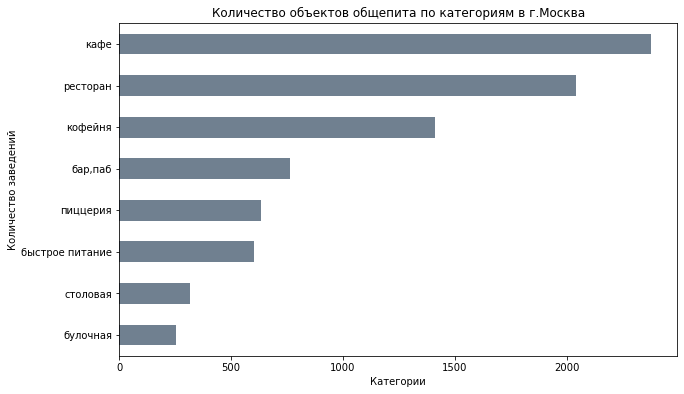

```python
# Для наглядности построим линейчатую диаграмму
# Создаём контейнер графика matplotlib и задаём его размер
plt.figure(figsize=(10, 6))
#строим диаграмму
food_places['category'].value_counts(ascending=True).plot(kind='barh',
                                            title='Количество объектов общепита по категориям в г.Москва',
                                            legend=False,
                                            ylabel='Количество заведений',
                                            xlabel='Категории',
                                            rot=0,
                                            color='slategray')
# Настраиваем график с помощью библиотеки matplotlib
plt.show()
```

### Задача 2

Какие административные районы Москвы присутствуют в данных? Исследуйте распределение количества заведений по административным районам Москвы, а также отдельно распределение заведений каждой категории в Центральном административном округе Москвы. Результат сопроводите подходящими визуализациями.

```python
# Проверяем распределение данных по значениям столбца district (район)
display('Распределение данных по значениям столбца district - абсолютные значения:')
display(food_places['district'].value_counts())
display('Распределение данных по значениям столбца district (район) - в %:')
display(round((food_places["district"].value_counts()/food_places.shape[0])*100,2))
```

```
'Распределение данных по значениям столбца district - абсолютные значения:'
```

```
district
Центральный административный округ         2241
Северный административный округ             898
Южный административный округ                892
Северо-Восточный административный округ     890
Западный административный округ             850
Восточный административный округ            798
Юго-Восточный административный округ        714
Юго-Западный административный округ         709
Северо-Западный административный округ      409
Name: count, dtype: int64
```

```
'Распределение данных по значениям столбца district (район) - в %:'
```

```
district
Центральный административный округ         26.68
Северный административный округ            10.69
Южный административный округ               10.62
Северо-Восточный административный округ    10.59
Западный административный округ            10.12
Восточный административный округ            9.50
Юго-Восточный административный округ        8.50
Юго-Западный административный округ         8.44
Северо-Западный административный округ      4.87
Name: count, dtype: float64
```

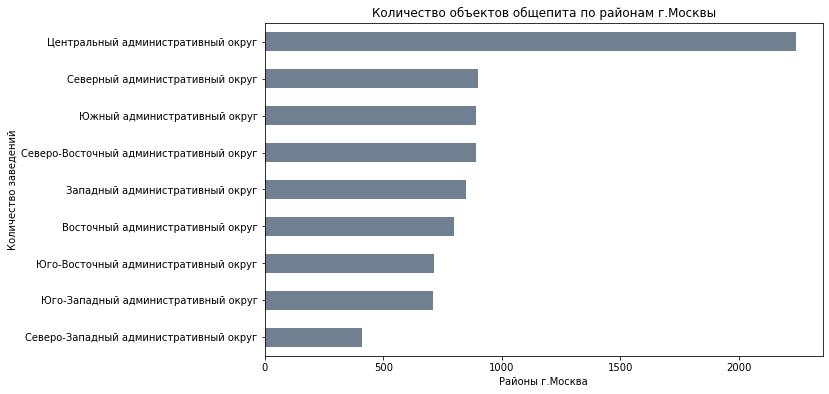

```python
# Для наглядности построим линейчатую диаграмму
# Создаём контейнер графика matplotlib и задаём его размер
plt.figure(figsize=(10, 6))
# Строим диаграмму
food_places['district'].value_counts(ascending=True).plot(kind='barh',
                                            title='Количество объектов общепита по районам г.Москвы',
                                            legend=False,
                                            ylabel='Количество заведений',
                                            xlabel='Районы г.Москва',
                                            rot=0,
                                            color='slategray')
# Настраиваем график с помощью библиотеки matplotlib
plt.show()
```

Исследуем заведения Центрального округа.

```python
# Выберем все заведения в Центральном районе
food_places_center = food_places.loc[food_places['district'].str.find('Центральный')!=-1]
```

```python
# Выведем данные по категориям заведений в Центральном районе
display('Распределение по категориям заведений в Центральном районе - абсолютные значения:')
display(food_places_center['category'].value_counts())
display('Распределение по категориям заведений в Центральном район - в %:')
display(round((food_places_center["category"].value_counts()/food_places_center.shape[0])*100,2))
```

```
'Распределение по категориям заведений в Центральном районе - абсолютные значения:'
```

```
category
ресторан           670
кафе               464
кофейня            427
бар,паб            364
пиццерия           113
быстрое питание     87
столовая            66
булочная            50
Name: count, dtype: int64
```

```
'Распределение по категориям заведений в Центральном район - в %:'
```

```
category
ресторан           29.90
кафе               20.71
кофейня            19.05
бар,паб            16.24
пиццерия            5.04
быстрое питание     3.88
столовая            2.95
булочная            2.23
Name: count, dtype: float64
```

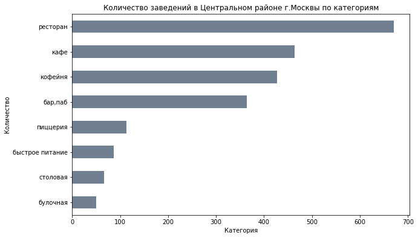

```python
#задаем размер графика
plt.figure(figsize=(10, 6))
# Строим линейчатую диаграмму заведений Центрального района по категориям
food_places_center['category'].value_counts(ascending=True).plot(kind='barh',
                                                    title='Количество заведений в Центральном районе г.Москвы по категориям',
                                                    legend=False,
                                                    ylabel='Количество',
                                                    xlabel='Категория',
                                                    rot=0,
                                                    color='slategray')
plt.show()
```

**Вывод:** Заведения общепита Центрального района по количеству можно условно разделить на три группы:

- рестораны,
- кафе, кофейни, бары,
- все остальные: пиццерии, быстрое питание, столовые и булочные.

### Задача 3

Изучите соотношение сетевых и несетевых заведений в целом по всем данным и в разрезе категорий заведения. Каких заведений больше — сетевых или несетевых? Какие категории заведений чаще являются сетевыми? Исследуйте данные, ответьте на вопросы и постройте необходимые визуализации.

```python
# Выведем данные принадлежности к сети заведений
display('Распределение по принадлежности к сети заведений - абсолютные значения:')
display(food_places['chain'].value_counts())
display('Распределение по принадлежности к сети заведений - в %:')
display(round((food_places["chain"].value_counts()/food_places.shape[0])*100,2))
```

```
'Распределение по принадлежности к сети заведений - абсолютные значения:'
```

```
chain
False    5199
True     3202
Name: count, dtype: int64
```

```
'Распределение по принадлежности к сети заведений - в %:'
```

```
chain
False    61.89
True     38.11
Name: count, dtype: float64
```

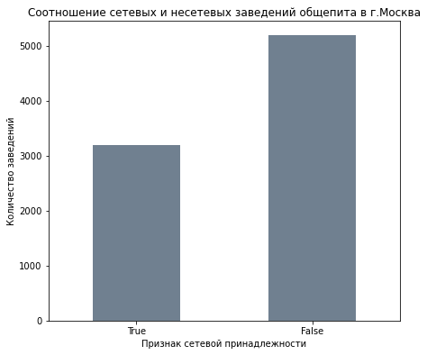

```python
# Строим столбчатую диаграмму
food_places['chain'].value_counts(ascending=True).plot(kind='bar',
                                            title='Соотношение сетевых и несетевых заведений общепита в г.Москва',
                                            legend=False,
                                            ylabel='Количество заведений',
                                            xlabel='Признак сетевой принадлежности',
                                            rot=0,
                                            color='slategray',
                                            figsize=(7, 6))
# Настраиваем график с помощью библиотеки matplotlib
plt.show()
```

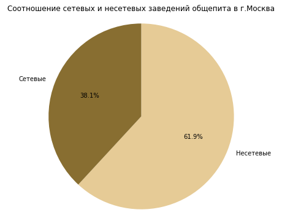

```python
# строим круговую диаграмму
fig, ax = plt.subplots(figsize=(8, 6))
ax.pie(food_places['chain'].value_counts(), labels=['Несетевые','Сетевые'], autopct='%1.1f%%', startangle=90,\
        colors=['#e6cb96','#886e31'], counterclock=False)
plt.axis('equal')
ax.set_title('Соотношение сетевых и несетевых заведений общепита в г.Москва')
plt.show()
```

```python
# Сгруппируем данные по признаку сети и категории и посчитайте количество
#food_places_grouped = food_places.groupby(['chain','category'])['id'].count().unstack(fill_value=0) - вариант написания с группировкой
food_places_grouped = pd.pivot_table(food_places, index='chain', columns='category', values='id', aggfunc='count')
#выведем на экран
display('Распределение данных по категориям и признаку сетевой принадлежности - абсолютные значения:')
display(food_places_grouped)
display('Распределение данных по категориям и признаку сетевой принадлежности - в % от общего количества заведений:')
display(round((food_places_grouped/food_places.shape[0])*100,2))
```

```
'Распределение данных по категориям и признаку сетевой принадлежности - абсолютные значения:'
```

| category chain | бар,паб | булочная | быстрое питание | кафе | кофейня | пиццерия | ресторан | столовая |
| --- | --- | --- | --- | --- | --- | --- | --- | --- |
| False | 596 | 99 | 371 | 1597 | 693 | 303 | 1313 | 227 |
| True | 168 | 157 | 232 | 779 | 719 | 330 | 729 | 88 |

```
'Распределение данных по категориям и признаку сетевой принадлежности - в % от общего количества заведений:'
```

| category chain | бар,паб | булочная | быстрое питание | кафе | кофейня | пиццерия | ресторан | столовая |
| --- | --- | --- | --- | --- | --- | --- | --- | --- |
| False | 7.09 | 1.18 | 4.42 | 19.01 | 8.25 | 3.61 | 15.63 | 2.70 |
| True | 2.00 | 1.87 | 2.76 | 9.27 | 8.56 | 3.93 | 8.68 | 1.05 |

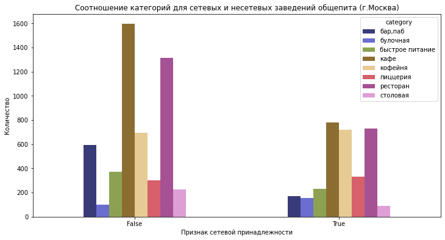

```python
#Строим график для всех категорий общепита - сетевых и несетевых
food_places_grouped.plot(kind='bar',
                        figsize=(12,6),
                        title='Соотношение категорий для сетевых и несетевых заведений общепита (г.Москва)',
                        ylabel='Количество',
                        xlabel='Признак сетевой принадлежности',
                        rot=0,
                        legend=True,
                        colormap='tab20b')
# Отображаем график
plt.show()
```

Видим, что среди несетевых самые популярные - это кафе и рестораны. Сетевые рассмотрим подробнее.

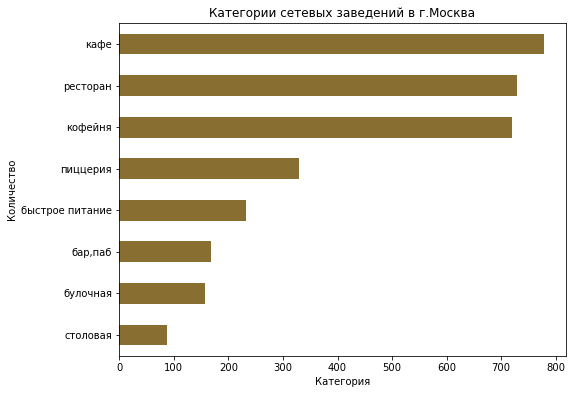

```python
# Выберем сетевые заведения
chain_true=food_places.loc[food_places['chain'] == True]
#Построим линейчатую диаграмму по категориям сетевых заведений
chain_true['category'].value_counts(ascending=True).plot(kind='barh',
                      figsize=(8,6),
                      title='Категории сетевых заведений в г.Москва',
                      ylabel='Количество',
                      xlabel='Категория',
                      rot=0,
                      color='#886e31',
                      legend=False)
# Отображаем график
plt.show()
```

**Вывод:** В Москве большинство заведений - несетевые - 5199 (61,9%). Среди несетевых заведений больше всего кафе - 1597 (30,7% от несетевых заведений) и ресторанов - 1313 (25,25%) и меньше всего булочных - 99 (1,9% от несетевых).

```python
#сгруппируем заведения по категориям и признаку принадлежности к сети
food_places_grouped = pd.pivot_table(food_places, index='category', columns='chain', values='id',\
                                     aggfunc='count', margins=True, margins_name='Все')
```

```python
#выведем сводные данные с итогами
food_places_grouped.columns=['Несетевые','Сетевые','Все']
food_places_grouped = food_places_grouped.sort_values('Сетевые', ascending=False)
```

```python
display('Соотношение сетевых и несетевых заведений среди категорий, в абс. значениях')
display(food_places_grouped)
```

```
'Соотношение сетевых и несетевых заведений среди категорий, в абс. значениях'
```

| category | Несетевые | Сетевые | Все |
| --- | --- | --- | --- |
| Все | 5199 | 3202 | 8401 |
| кафе | 1597 | 779 | 2376 |
| ресторан | 1313 | 729 | 2042 |
| кофейня | 693 | 719 | 1412 |
| пиццерия | 303 | 330 | 633 |
| быстрое питание | 371 | 232 | 603 |
| бар,паб | 596 | 168 | 764 |
| булочная | 99 | 157 | 256 |
| столовая | 227 | 88 | 315 |

```python
#Преобразуем нужные столбцы во float, чтобы избежать предупреждения
cols_to_fix = ['Несетевые', 'Сетевые']
food_places_grouped[cols_to_fix] = food_places_grouped[cols_to_fix].astype(float)
```

```python
# Считаем процент для обоих столбцов сразу
food_places_grouped[cols_to_fix] = (
    food_places_grouped[cols_to_fix]
    .div(food_places_grouped['Все'], axis=0) * 100
).round(2)
```

```python
display('Соотношение сетевых и несетевых заведений среди категорий, в %')
display(food_places_grouped.sort_values(by='Сетевые', ascending=False))
```

```
'Соотношение сетевых и несетевых заведений среди категорий, в %'
```

| category | Несетевые | Сетевые | Все |
| --- | --- | --- | --- |
| булочная | 38.67 | 61.33 | 256 |
| пиццерия | 47.87 | 52.13 | 633 |
| кофейня | 49.08 | 50.92 | 1412 |
| быстрое питание | 61.53 | 38.47 | 603 |
| Все | 61.89 | 38.11 | 8401 |
| ресторан | 64.30 | 35.70 | 2042 |
| кафе | 67.21 | 32.79 | 2376 |
| столовая | 72.06 | 27.94 | 315 |
| бар,паб | 78.01 | 21.99 | 764 |

```python
#еще раз получим сводную таблицу, но уже без итогов - для построения графика
food_places_grouped = pd.pivot_table(food_places, index='category', columns='chain', values='id',aggfunc='count')
food_places_grouped.columns=['Несетевые','Сетевые']
#отсортируем для наглядности
food_places_grouped = food_places_grouped.sort_values(by='Сетевые', ascending=False)
```

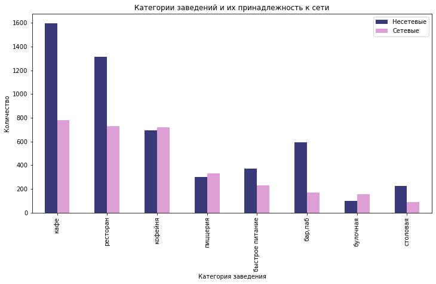

```python
#Строим график для всех категорий общепита - сетевых и несетевых
food_places_grouped.plot(kind='bar',
                        figsize=(12,6),
                        title='Категории заведений и их принадлежность к сети',
                        ylabel='Количество',
                        xlabel='Категория заведения',
                        rot=90,
                        legend=True,
                        colormap='tab20b')
# Отображаем график
plt.show()
```

**Вывод:** Категории заведений среди которых сетевых больше, чем несетевых:

- булочные - сетевых 157-61,33% среди всех булочных;
- пиццерии - сетевых 330-52,13% среди всех пиццерий;
- кофейни - сетевых 719-50,92% среди всех кофеен.